# Final Project - Applied Data Science Spring 19

Eric Kavales

April 22, 2019

## Gapminder data set

The data is from gapminder.csv, located in [Final Project Folder](https://github.com/erkavale/Applied-Data-Science-s19/tree/master/Final%20Project) and is not from the gapminder set available in R.

## Research questions

#### There are many things, in this dataset, that are of interest.

#### We will focus on the following questions:

##### How has population changed over time?

-Were there any dramatic changes or do all regions experience something similar?

##### Is life expectancy the same for all regions of the world?

##### How has life expectancy changed over time per region?

-Were there any dramatic changes?  
-Did all regions experience the same changes, if any?

##### Can income predict life expectancy?

##### Does income have an effect on life expectancy?

-If so, in which region would one want to live to maximize income and life expectancy?

### Summary of data

Gapminder contains six variables: Country, Year, life (life expectancy), population, income (per capita), and region. It has 41284 observations. Missing values are located in population (25817 N/A values) and income (2341 N/A values). Their types are factor, int, num, factor, int, and factor respectively. Year ranges from 1800 to 2015.  
life ranges from 1 to 84.1  
population ranges from 1,548 to 1.37 billion income ranges from 142 to 182668

### Wrangling of data

Upon inspection, population was of type factor. This needed to be changed as it should not be a categorical variable. I also altered the data in the variable population. Before 1950, data was only recorded every 10 years. I added the previous year to the next until the next data point, using fill().

## Analysis of Data

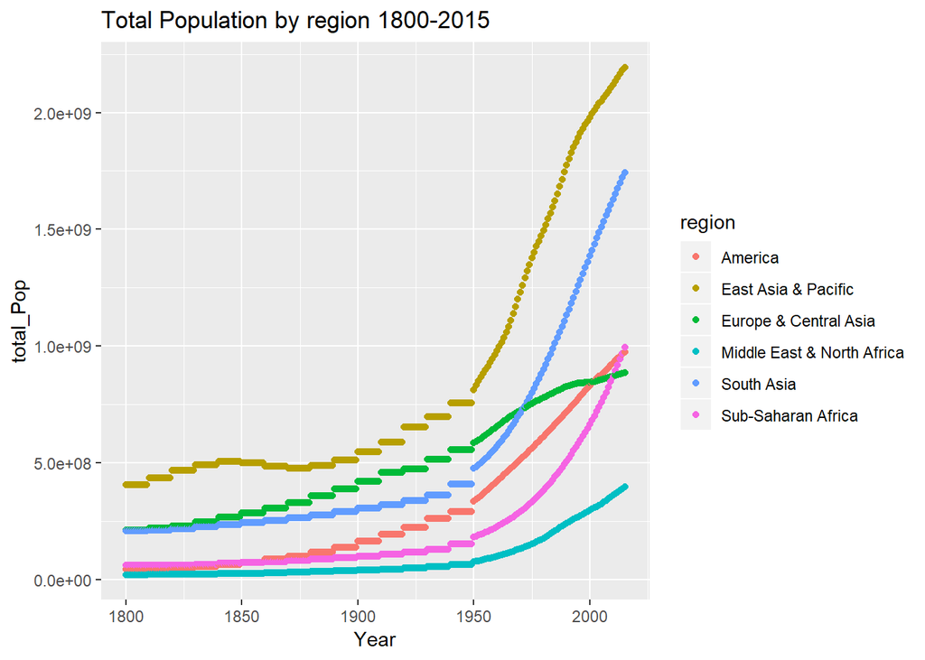

This plot shows us that most regions are following an exponential growth curve, with the exception on Europe & Central Asia. Their population slightly declined in the 1990s and has resumed growth but at a much lower pace. There is no way to determine, from this data set, why their population growth has slowed. In just the last decade the population of Sub-Saharan Africa has overtaken America and Europe & Central Asia, and it is now the third most populous region.

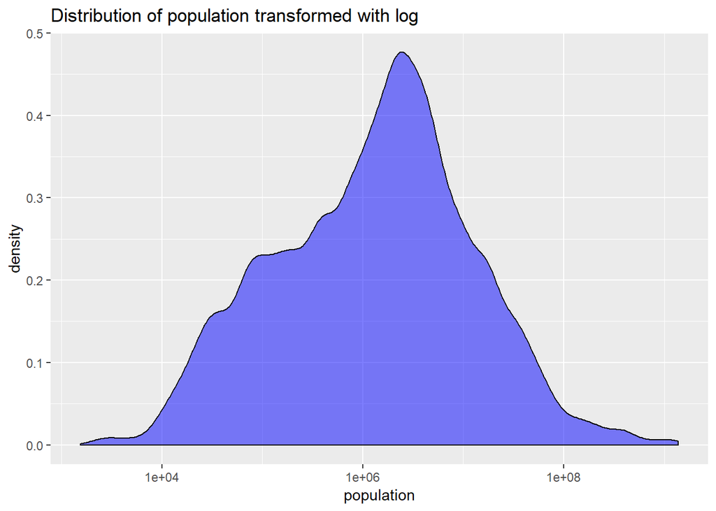

The above graph shows the distribution of population on a log10 scale. The distribution of the population was so right skewed that it was not worth displaying the graph and is most likely not normal. This graph appears to be close to normal but let us verify with the below Q-Q plots.

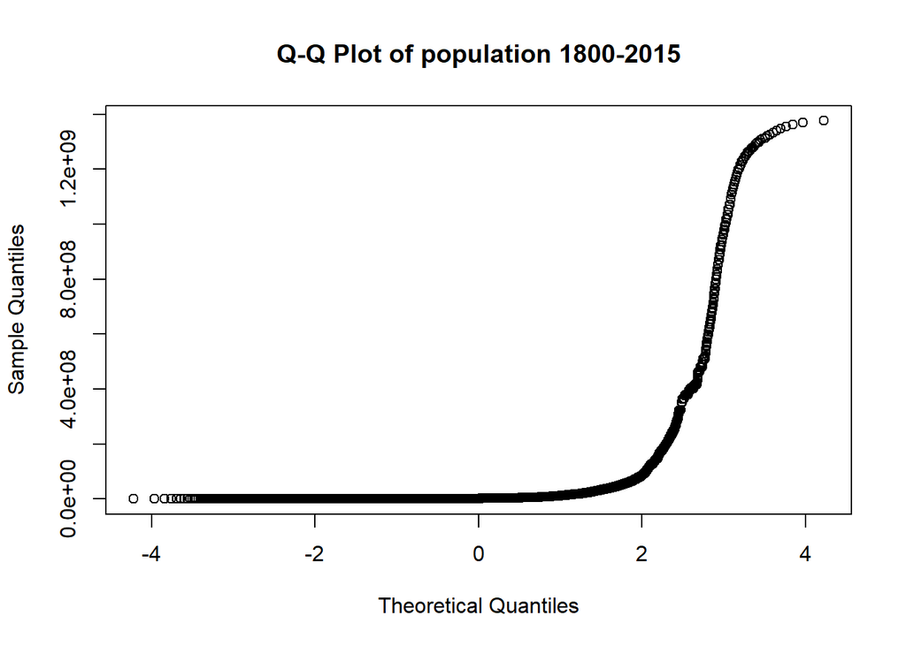

As hypothesized, the distribution of the population is not normal.

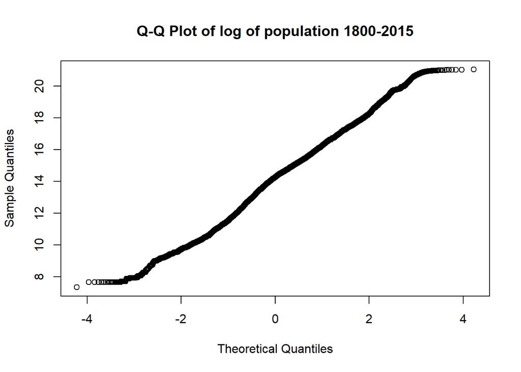

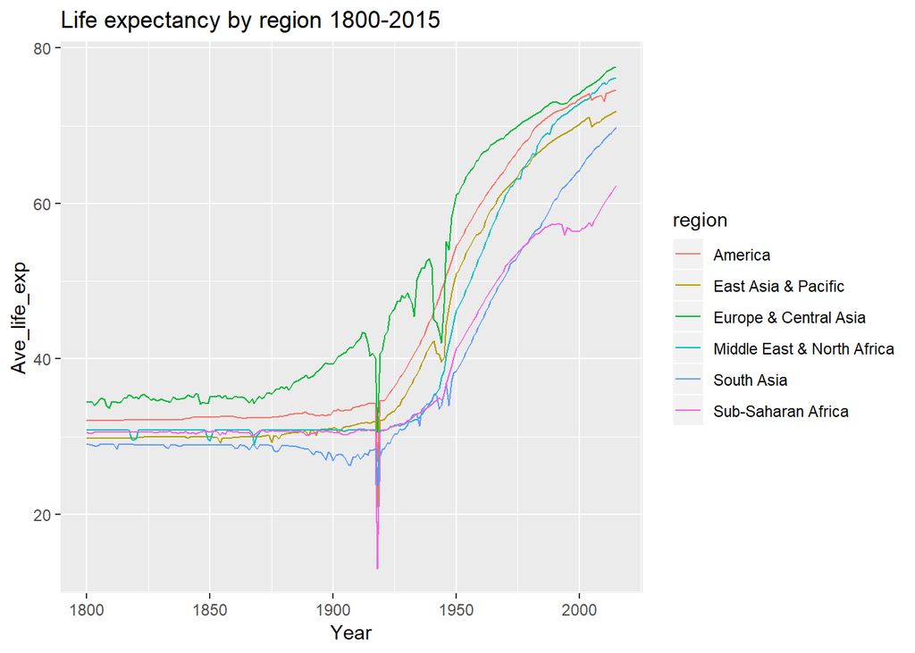

We can see that life expextancy has increased very much over time, except for the drops near 1915-1920 range and 1940-45 range. This could be due to poor data recording but it is more likely that it is reflecting the massive loss of life during World War 1 and 2.

##### We can see from the above plots that population growth data is complete from 1950 to 2015 and life expectancy increases the most from 1950 to 2015. We will focus on this time range for the remained of the analysis.

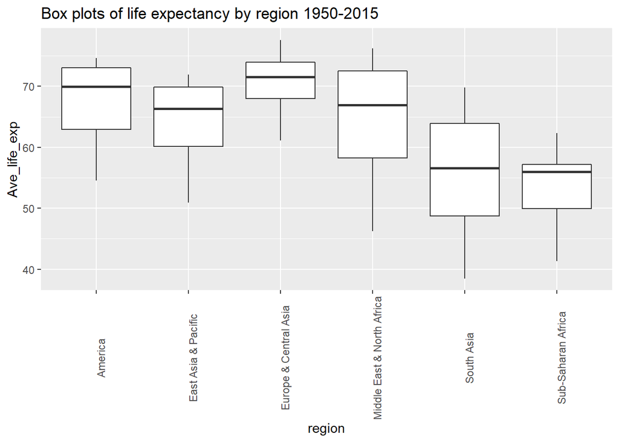

The above distributions tell us that Europe and Central Asia have the highest average life expectancy, with a comparatively small range. America comes in a close second, and has a larger range.

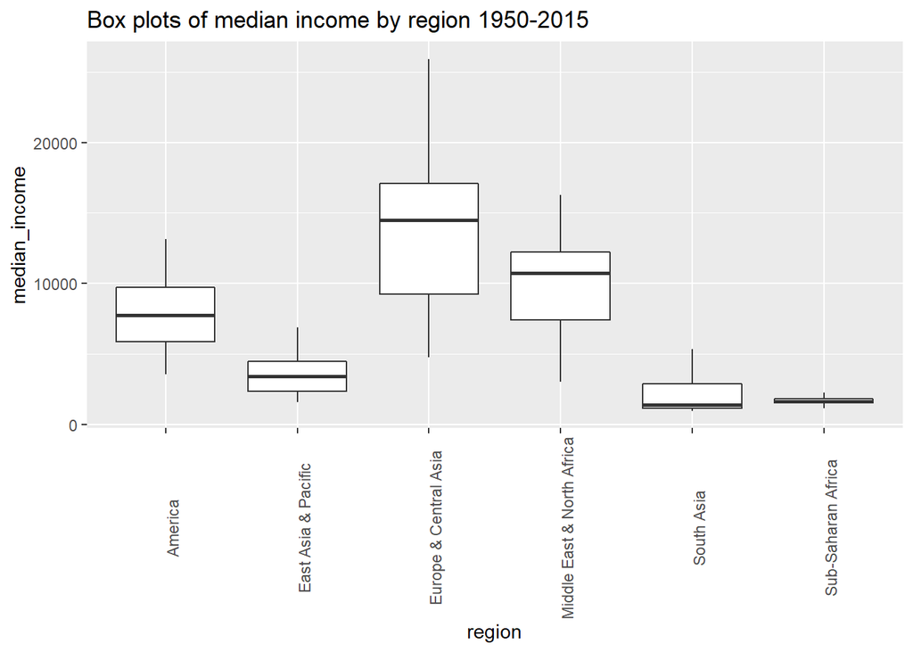

This plot clearly shows that Europe and Central Asia have the highest median income. The next closest, Middle East & North Africa, are several thousand dollars lower, with America following a similar drop to take third. Sub-Saharan Africa appears to have almost no range in income.

It appears the is a link between median income and average life expectancy. To be sure let us calculate the correclation coefficient.

With a value of 0.758489 there appears to be a strong positive correlation between life expectancy and income.

**Now let us use regression analysis to see if income (independent variable) can predict life expectancy (dependent variable).**

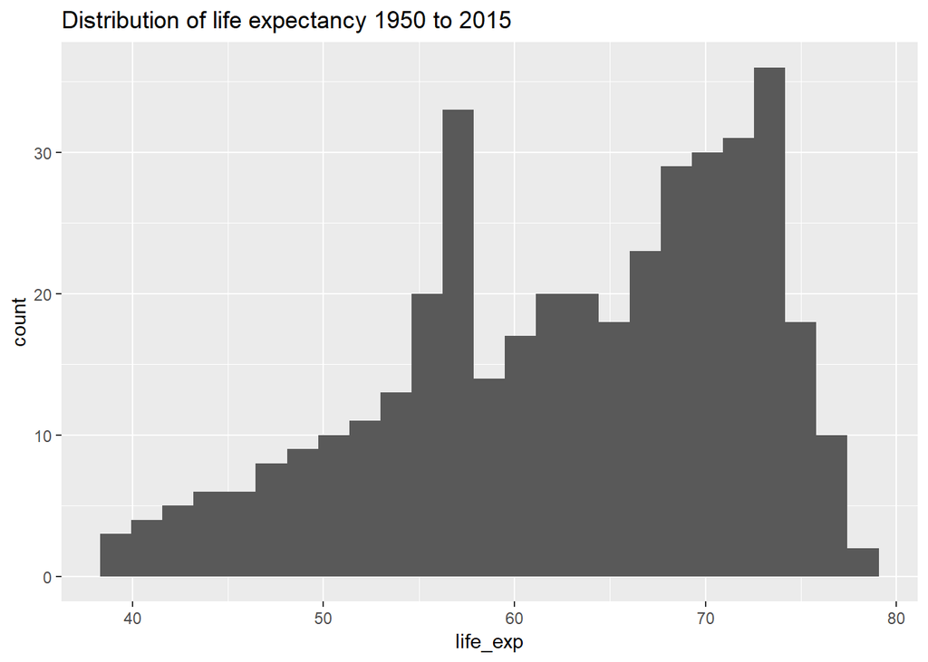

The distribution of our dependent variable is left skewed and bimodal. Regression will probably not work on this variable but let us test to find out.  
Let’s first look at the regression summary table.

```
##
## Call:
## lm(formula = Ave_life_exp ~ median_income, data = year_1950to2015)
##
## Residuals:
##      Min       1Q   Median       3Q      Max
## -17.2799  -3.8848   0.6201   4.1035  10.0815
##
## Coefficients:
##                Estimate Std. Error t value Pr(>|t|)
## (Intercept)   5.453e+01  4.729e-01   115.3   <2e-16 ***
## median_income 1.279e-03  5.537e-05    23.1   <2e-16 ***
## ---
## Signif. codes:  0 '***' 0.001 '**' 0.01 '*' 0.05 '.' 0.1 ' ' 1
##
## Residual standard error: 6.051 on 394 degrees of freedom
## Multiple R-squared:  0.5753, Adjusted R-squared:  0.5742
## F-statistic: 533.7 on 1 and 394 DF,  p-value: < 2.2e-16
```

The regression line is built using life_exp=54.53 + .00128(income)

The p-values of the intercept and slope are basically 0, indicating these variables have statistical significance.

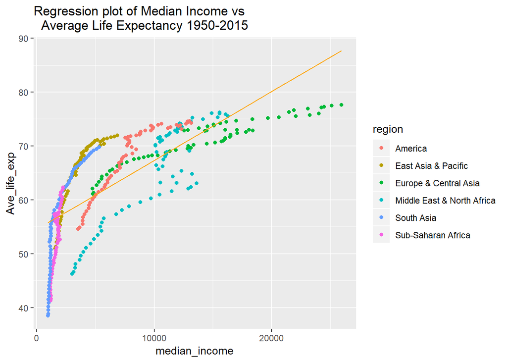

The regression line does seem to fit the data somewhat. We should verify using a residuals vs fitted plot.

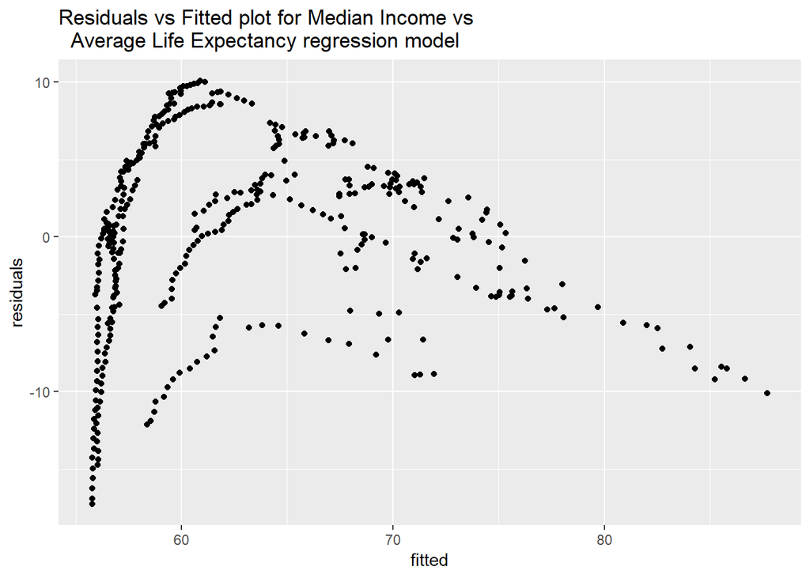

The residual vs fitted plot shows a definite pattern. Heterogeneity is present. Due to this plot and the distribution plot we can see that the assumptions of normality and constant variance are violated. This model is not a good fit for the data. Let us try a log transformation to see if this improves our ability to do regression.

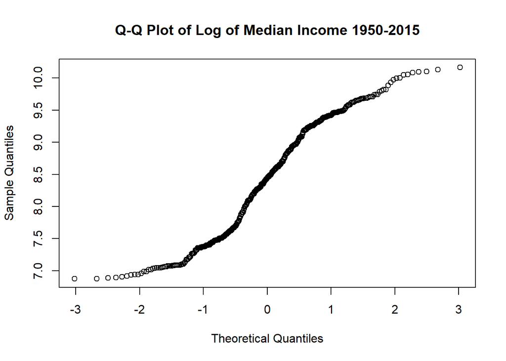

Transforming median income shows a much closer to normal distribution. This should allow us to proceed.

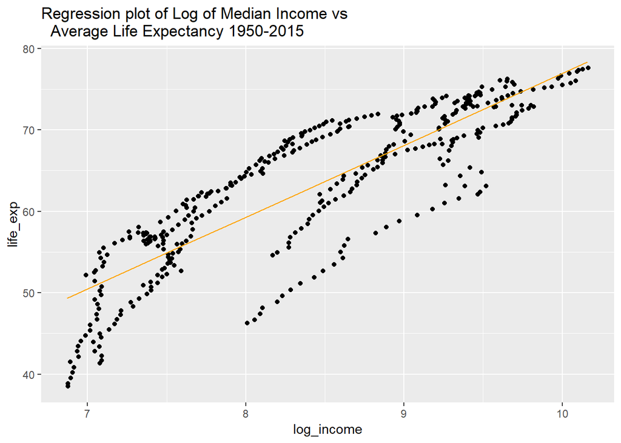

The regression look much better than previous and may allow us to predict life expectancy using income. Let us verify with a residuals vs fitted plot.

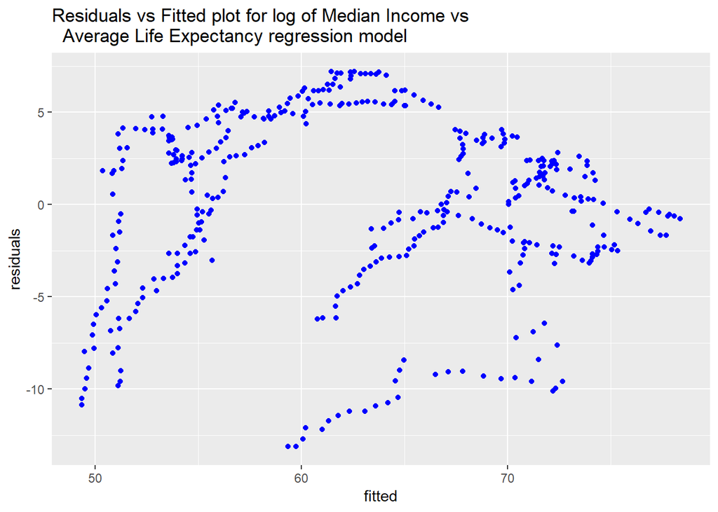

Transformation did not help get much closer to homogeneity.  
Model not a good fit. Variance assumption violated.

It does appear that you are more likely to live longer if you have a higher income, but overall it does not appear that earning a particular income will predict your life expenctancy.  
Let’s look at a K-means cluster to see if we can further determine how income might affect life expectancy.

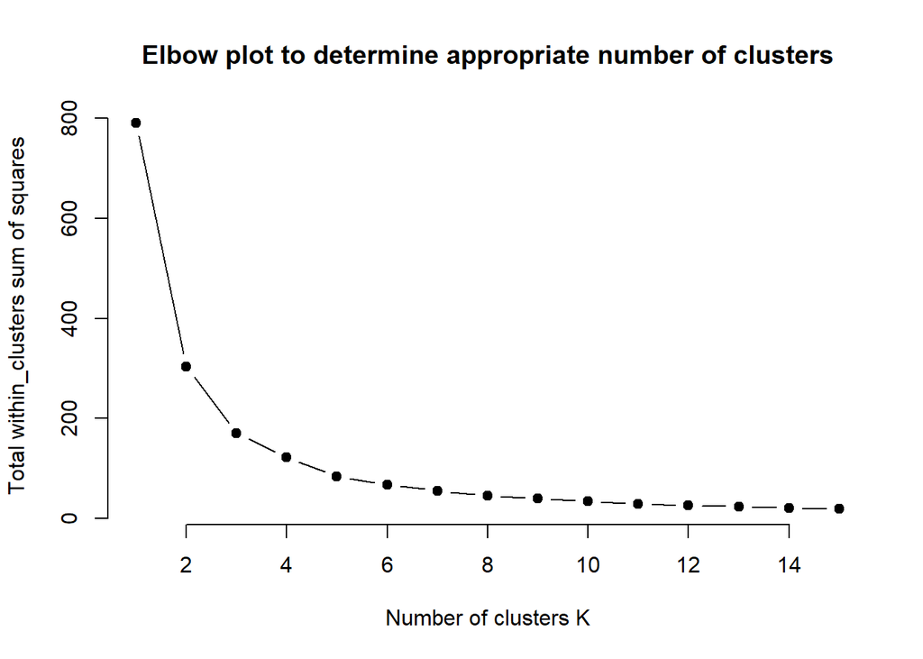

We can see from the above elbow plot that the optimal number of clusters is 3.

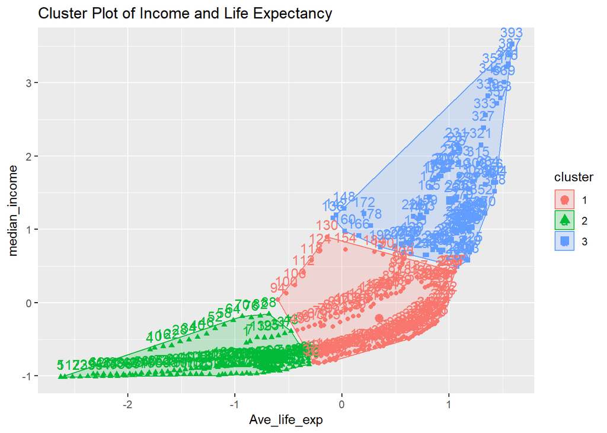

# Summary of Analysis